# 統計計算與模擬 Homework05

105354003林芃彣 ＆ 105354030陳媚

June, 13, 2017

## 第一題

Try at least three different methods to find the estimates of B and C for the Gompertz model, using the Taiwan data in 2016. You may count “nlminb”, “nls” or “opt” as one of the method (for replacing Newton’s method). Also, similar to what we saw in the class, discuss the influence of starting points to the number of iterations. You may choose the male data or female data. (Bonus: Compare the results of different counties.)

```r
pop<- read.csv('population1.csv',header=F)  #人口
death<- read.csv('death1.csv',header = F)  #死亡人數
male.p<-unlist(c(apply(matrix(unlist(pop[-1]),nrow=20,byrow=TRUE),1,sum),pop[101]))  #分組
male.d<-unlist(c(apply(matrix(unlist(death[-1]),nrow=20,byrow=TRUE),1,sum),death[101])) #分組
n<- male.p+male.d  #總人口
p<- 1-male.d/n  #生存率
x<- -3+5*(1:21)  #取中位數
```

#### 方法一：wls

```r
mywls<-function(weights){
  wls<-lm(log(-log(p))~x,weights = weights)
  cwls<-exp(wls[[1]][2])  #function中的beta
  bwls<-exp(wls[[1]][1]-log(cwls-1)-log(log(cwls)))
  cbind(bwls,cwls)
}
wls<-rbind(mywls(rep(1,21)),mywls(sqrt(n)),mywls(log(n)))
```

#### 方法二：nm

```r
nmf1<-function(y){
  b<-y[2]
  c<-y[1]
  w<-rep(1,21)
  tot<-NULL
  for(i in 1:length(p))
    tot<-sum(tot,w[i]*(p[i]-exp((-b*c^x[i])*(c-1)/log(c)))^2)
  tot
}
nm1<-optim(c(0.05,0.99),nmf1)$par
nm4<-optim(c(0.5,0.9),nmf1)$par

nmf2<-function(y){
  b<-y[2]
  c<-y[1]
  w<-sqrt(n)
  tot<-NULL
  for(i in 1:length(p))
    tot<-sum(tot,w[i]*(p[i]-exp((-b*c^x[i])*(c-1)/log(c)))^2)
  tot
}
nm2<-optim(c(0.05,0.99),nmf2)$par

nmf3<-function(y){
  b<-y[2]
  c<-y[1]
  w<-n
  tot<-NULL
  for(i in 1:length(p))
    tot<-sum(tot,w[i]*(p[i]-exp((-b*c^x[i])*(c-1)/log(c)))^2)
  tot
}
nm3<-optim(c(0.05,0.99),nmf3)$par
nm<-rbind(nm1,nm2,nm3)
```

#### 方法三：mle

```r
mlef<-function(y){
  b<-y[1]
  c<-y[2]
  tot<-NULL
  for(i in 1:length(p))
    tot<-sum(tot,((n[i]-male.d[i])*b*c^x[i]*(c-1)/log(c)-male.d[i]*log(1-exp((-b*c^x[i])*(c-1)/log(c)))))
  tot
}
mle<-optim(c(0.05,0.99),mlef)$par
mle1<-optim(c(0.5,0.9),mlef)$par
```

#### 結果1：對比參數BC的估計結果

```r
result1<-rbind(wls,nm,mle)
colnames(result1)=c('參數B','參數C')
rownames(result1)=c('WLS-1','WLS-sqrt(n)','WLS-n','NM-1','NM-sqrt(n)','NM-log(n)','MLE')
result1
```

```
##                    參數B     參數C
## WLS-1       0.0175790315 1.0818619
## WLS-sqrt(n) 0.0176351498 1.0818107
## WLS-n       0.0174166326 1.0820265
## NM-1        0.0283437500 1.0101094
## NM-sqrt(n)  0.0270929565 0.9962993
## NM-log(n)   0.0277451668 1.0054134
## MLE         0.0000901613 1.0851556
```

#### 結果2：對比NM MLE的起始位置選取差異

```r
result2<-rbind(nm4,mle1)
colnames(result2)=c('參數B','參數C')
rownames(result2)=c('nm','mle')
result2
```

```
##            參數B     參數C
## nm  2.785156e-02 0.9655664
## mle 9.029183e-05 1.0851424
```

#### 迭代次數的比較

```r
nm.iter<-matrix(nrow=10,ncol=10)
for(i in 1:10){
  for(j in 1:10){
    nm.iter[i,j]<-optim(c(0.019+0.01*i,0.89+0.01*j),nmf1)$counts[1]
  }
}
nm.iter
```

```
##       [,1] [,2] [,3] [,4] [,5] [,6] [,7] [,8] [,9] [,10]
##  [1,]   13   13   13   13   13   13   13   13   13    13
##  [2,]   17   17   17   17   17   17   17   17   17    17
##  [3,]   21   21   21   19   19   19   19   19   21    17
##  [4,]   19   19   19   19   19   19   19   19   19    19
##  [5,]   19   19   19   19   19   21   15   15   21    21
##  [6,]   21   21   19   19   19   17   17   17   15    17
##  [7,]   21   21   21   21   21   23   23   21   21    23
##  [8,]   21   19   19   19   21   19   19   19   19    19
##  [9,]   19   19   19   19   21   19   19   21   25    23
## [10,]   17   17   17   17   19   17   19   19   21    13
```

```r
mle.iter<-matrix(nrow=10,ncol=10)
for(i in 1:10){
  for(j in 1:10){
    mle.iter[i,j]<-optim(c(0.019+0.01*i,0.89+0.01*j),mlef)$counts[1]
  }
}
mle.iter
```

```
##       [,1] [,2] [,3] [,4] [,5] [,6] [,7] [,8] [,9] [,10]
##  [1,]  169  129  213  157  167  165  129  111  119   141
##  [2,]  123  119  133  137  143  149  191  121  153   123
##  [3,]  111  117  113  145  211  125  189  123  109   121
##  [4,]  127  127  157  131  137  175  119  147  161   173
##  [5,]  143  199  129  145  165  149  141  121  133   257
##  [6,]  117  159  157  179  107  131  149  125  103   143
##  [7,]  139  121  139  177  177  131  107  127  117   141
##  [8,]  157  119  129  147  125  179  161  157  153   163
##  [9,]  151  183  177  149  141  231  211  175  147   157
## [10,]  145  125  153  143  147  167  139  241  123   177
```

## 第二題

Evaluate the CDF of standard normal distribution $\Phi(x)$ using the method of Important Sampling and other Variance Reduction Methods (at least two different methods). Consider x = 6, 5, 4, 3.5, 3, 2.5, 2.

- 目標：計算標準常態的累積機率，并利用3種方法縮減變異數
- 做法：
  1. 利用蒙地卡羅方法計算 Xi 服從標準常態下的累積機率，i=1,2…7 ，同時與利用 pnorm 函數得到的機率值作為標準進行對比，其做法如下:從已知的標準常態分配中抽出 10000 個值，并計算抽出的值中小於 Xi 的個數，記為 a1 ，則 a1/10000 就是 Xi 的累積積累值，重複上述步驟 1000 次，計算 1000 個 a1 的平均數及變異數
  2. 縮減變異數
     1. Importance Sampling：想要用相似的分配 f1 逼近目標分配 f2 (標準常態)，計算其累計機率值，令 f1 為也常態分配，平均數=目標值 (-6,-5,-4,-3.5,-3,-2.5,-2) ,變異數=1，從 f1、f2 分別抽取 1 萬個觀測值，計算f1中小於平均數的觀測值與 f2 的比值的機率 t1 ，重複 1 千次，計算 t1 的平均數及變異數
     2. Antithetic Variate：找一個和目標值完全負相關的數，利用 rnorm 生成 1 萬的值 Xi,這裡取 yi=-xi,(x+y)/2 是原本目標值的不偏估計，且兩者負相關，因此達到縮減變異數的目的
     3. Stratified Sampling：有點類似分層抽樣，先將 CDF 範圍 unif[0,1] 均等分為 5 份，每個區間抽取相同數量的樣本 xi ,設 x=(1/xi)-1，將 x 代入標準常態的 pdf 計算機率,重複 1000 次計算其平均數
- 結果：整體而言，ImportanceSampling 估計的累積機率最為準確，特別在 x 越小時和其他方法相比估計仍然較為準確， Antithetic Variate 和蒙地卡羅方法估計效果稍遜，且X越小估計效果越差， Stratified Sampling 估計效果最不理想，差異最大，可能是因為類似分層抽樣，每個區間都抽取了相同的樣本數有影響

#### stand value

```r
x<-c(-6,-5,-4,-3.5,-3,-2.5,-2)
stand<-pnorm(x)
```

#### 蒙地卡羅

```r
mc.f<-function(n,value){
  t0=NULL
  for(i in 1:n){
    x=rnorm(10000)
    a1=sum(x<=value)/10000
    t0=c(t0,a1)
  }
  out=rbind(mean(t0),var(t0))
  rownames(out)=c('estimate','variance')
  out
}
mc=cbind(mc.f(1000,-6),mc.f(1000,-5),mc.f(1000,-4),mc.f(1000,-3.5),mc.f(1000,-3),mc.f(1000,-2.5),mc.f(1000,-2))
```

#### importance sampling

```r
imposam.f<-function(n,value){
  t1=NULL
  for(i in 1:n){
    x=rnorm(10000,value,1)
    zpdf=function(x){1/sqrt(2*pi)*exp(-(x^2)/2)}
    g=function(x){1/sqrt(2*pi)*exp(-(x-value)^2/2)}
    h=ifelse(x<value,1,0)
    fg=h*zpdf(x)/g(x)
    a1=sum(fg)/10000
    t1=c(t1,a1)
  }
  out=rbind(mean(t1),var(t1))
  rownames(out)=c('estimate','variance')
  out
}
imposam=cbind(imposam.f(1000,-6),imposam.f(1000,-5),imposam.f(1000,-4),imposam.f(1000,-3.5),imposam.f(1000,-3),imposam.f(1000,-2.5),imposam.f(1000,-2))
```

#### antithetic variate

```r
anti.f<-function(n,value){
  t2=NULL
  for(i in 1:n){
    x1=rnorm(10000)
    x2=-x1
    a=(sum(x1<=value)+sum(x2<=value))/2
    a1=a/10000
    t2=c(t2,a1)
  }
  out=rbind(mean(t2),var(t2))
  rownames(out)=c('estimate','variance')
  out
}
anti=cbind(anti.f(1000,-6),anti.f(1000,-5),anti.f(1000,-4),anti.f(1000,-3.5),anti.f(1000,-3),anti.f(1000,-2.5),anti.f(1000,-2))
```

#### stratified sampling

```r
stram.f<-function(n,value){
  t4=NULL
  for(i in 1:n){
    x=c(runif(2000,0,0.2),runif(2000,0.2,0.4),runif(2000,0.4,0.6),runif(2000,0.6,0.8),runif(2000,0.8,1))
    x1=(1/x)-1
    g=1/sqrt(2*pi)*exp(-((x1-value)^2)/2)
    a1=mean(g)*0.2
    t4=c(t4,a1)
  }
  out=rbind(mean(t4),var(t4))
  rownames(out)=c('estimate','variance')
  out
}
stram=cbind(stram.f(1000,-6),stram.f(1000,-5),stram.f(1000,-4),stram.f(1000,-3.5),stram.f(1000,-3),stram.f(1000,-2.5),stram.f(1000,-2))
```

#### comparison

```r
all=rbind(stand,mc[1,],imposam[1,],anti[1,],stram[1,],mc[2,],imposam[2,],anti[2,],stram[2,])
colnames(all)=c('x=-6','x=-5','x=-4','x=-3.5','x=-3','x=-2.5','x=-2')
rownames(all)=c('stand value','mc.value','imposam.value','anti.value','stram.value','mc.var','imposam.var','anti.var','stram.var')
all
```

```
##                       x=-6         x=-5         x=-4       x=-3.5
## stand value   9.865876e-10 2.866516e-07 3.167124e-05 2.326291e-04
## mc.value      0.000000e+00 2.000000e-07 3.210000e-05 2.374000e-04
## imposam.value 9.854682e-10 2.864946e-07 3.164973e-05 2.327226e-04
## anti.value    0.000000e+00 1.000000e-07 3.120000e-05 2.362000e-04
## stram.value   1.534387e-10 4.298498e-08 4.529907e-06 3.228906e-05
## mc.var        0.000000e+00 1.997998e-11 3.342933e-09 2.394519e-08
## imposam.var   6.488255e-22 4.777538e-17 4.194234e-13 2.064902e-11
## anti.var      0.000000e+00 4.994995e-12 1.488048e-09 1.140096e-08
## stram.var     1.478174e-24 8.734280e-20 5.871884e-16 2.436383e-14
##                       x=-3       x=-2.5         x=-2
## stand value   1.349898e-03 6.209665e-03 2.275013e-02
## mc.value      1.339400e-03 6.189000e-03 2.277430e-02
## imposam.value 1.349922e-03 6.209563e-03 2.274927e-02
## anti.value    1.333800e-03 6.225100e-03 2.269045e-02
## stram.value   1.807155e-04 7.964685e-04 2.768363e-03
## mc.var        1.287964e-07 5.928318e-07 2.234444e-06
## imposam.var   6.834249e-10 1.123322e-08 1.176489e-07
## anti.var      6.910166e-08 3.000150e-07 1.094496e-06
## stram.var     5.485254e-13 7.862347e-12 6.926522e-11
```

## 第三題

Let $X_i, i=1,2,...,5$ be independent exponential random variables each with mean 1, and consider the quantity $\theta$ defined by $\theta=P\{\sum_{i=1}^{5}iX_i \geq 21.6\}$ Propose at least three simulation methods to estimate and compare their variances.

- Monte Carlo 方法，在不做任何轉換下，依據題目意思產生五個服從 exp(1) 的變數，計算一千次中 $\sum_{i=1}^{5}iX_i \geq 21.6$ 發生的次數，機率值極為$\theta$ 的估計值，以這樣的方式模擬一千次後得到 1000 個$\theta$的估計值，計算得估計值的平均數與變異數。
- Antithetic 方法是產生一組新的變數跟原來的變數具有相同分配，但兩組變數間具有負的相關性，在估計參數時用兩組變數估計出的估計值平均，以同樣的方式模擬一千次，得到 1000 個$\theta$的估計值，計算得估計值的平均數與變異數。

```r
#Monte Carlo SRS vs. Antithetic
result <- matrix(ncol = 1000, nrow = 2)
for (i in 1:1000){
  t=matrix(ncol = 1000, nrow = 2)
  for (j in 1:1000){
    u=runif(5)
    x=-log(u)
    a=sum(c(1:5)*x)
    y=-log(1-u)
    b=sum(c(1:5)*y)
    t[,j]=c(a,b)}
  e=apply(t,1,function(x) sum(x>=21.6)/1000)
  result[1,i]=e[1]
  result[2,i]=(e[1]+e[2])/2}
```

```
##       Monte Carlo   Antithetic
## mean 0.1686570000 1.686605e-01
## var  0.0001531205 5.915314e-05
```

- Control Variance : runs = 10000 才會比較準確

```r
t=vector(length=10000)
for (i in 1:10000){
  e=vector(length=10)
  for (j in 1:10){
    u=runif(5)
    x=-log(u)
    e[j]=sum(c(1:5)*x)}
  t[i]=sum(e >= 21.6)/10}
u2=runif(10000)
th=c((u2<=t)*1)
mean(th)
```

```
## [1] 0.1631
```

```r
var(th)/10000
```

```
## [1] 1.36512e-05
```

## 第四題

Evaluate the following quantity by both numerical and Monte Carlo integration, and compare their errors with respect to the numbers of observations used. Also, propose at least two simulation methods to reduce the variance of Monte Carlo integration and compare their variances.
$$\theta=\int_0^1 e^{x^2} dx$$

#### numerical

```r
x=c(1:10^7)/10^7  #0-1  切成很多個
y=exp(x^2)
nu=cbind(mean(y),0)
nu
```

```
##          [,1] [,2]
## [1,] 1.462652    0
```

#### monte carlo

```r
mc= matrix(ncol = 2, nrow = 10)
t5=vector(length = 1000)
for(k in 1:10){
  for(i in 1:1000){
    x=runif(1000*k)
    f=exp(x^2)
    t5[i]=mean(f)
  }
  mc[k,]=cbind(mean(t5),var(t5))
}
```

#### 差異

```
##  [1]  6.824740e-04 -5.378986e-05 -2.176371e-04  1.135006e-04  1.794241e-04
##  [6]  2.832464e-04 -1.113239e-04 -1.227362e-04  4.943667e-04  2.307162e-04
```

#### antithetic variate

```r
t6=NULL
for(i in 1:1000){
  x1=runif(10000)
  x2=1-x1
  f=function(x){exp(x^2)}
  a=(f(x1)+f(x2))/2
  t6=c(a,t6)
}
an=cbind(mean(t6),var(t6))
```

#### stratified sampling

```r
t7=NULL
for(i in 1:1000){
  x=c(runif(2000,0,0.2),runif(2000,0.2,0.4),runif(2000,0.4,0.6),runif(2000,0.6,0.8),runif(2000,0.8,1))
  f=exp(x^2)
  a1=mean(f)
  t7=c(a1,t7)
}
ss=cbind(mean(t7),var(t7))
```

#### comparison

```
##              value     variance
## numerical 1.462652 0.000000e+00
## mc        1.461969 2.267862e-04
## mc        1.462706 1.139336e-04
## mc        1.462869 7.650457e-05
## mc        1.462538 5.380653e-05
## mc        1.462472 4.472514e-05
## mc        1.462369 3.577929e-05
## mc        1.462763 3.351602e-05
## mc        1.462775 2.839135e-05
## mc        1.462157 2.472451e-05
## mc        1.462421 2.076598e-05
## anti      1.462660 2.795023e-02
## strat     1.462611 1.555599e-06
```

## 第五題

- 依據題目指定方式建立 data，使用三種密度估計方法
  - histogram density estimator：參照課本，給訂寬度h，將資料依據 h 分為 m 等份
    i.e. 最大值=a、最小值=b，h = (a-b)/m，then the density estimate of $x \in [a,b]$ is
    $$\hat{f}(x) = \frac{1}{n}\sum_{j=1}^{m}\frac{n_j}{h}*I{x \in [a_{j-1},a_j]}$$
  - naive density estimator：參照課本，Instead of rectangle, allow the weight is centered on x :
    $$\hat{f}(x) = \frac{1}{n}\sum_{i=1}^{n}\frac{1}{h} w(\frac{x-x_i}{h}), where w(x) = 1/2 ,if |x| < 1$$
  - kernel density estimator：kernel 方法有很多種類，在此使用 Guassian kernal：
    $$\hat{f}(x) = \frac{1}{n}\sum_{i=1}^{n}\frac{1}{h} w(\frac{x-(x_i)}{h}),where \int_{-\infty}^{\infty}K(t)dt = 1$$

```r
# data
x0=runif(100)
x1=rnorm(100,-2,1)
x2=rnorm(100,2,1)
x=(x0<0.5)*x1+(x0>0.5)*x2
# histogram density estimator
histest=function(x,h){
  w=function(x,a,b){
    if (x<=b & x>=a) {return(1)}
    else {return(0)}}
  n=length(x)
  sx=seq(min(x),max(x),by=h)
  a=sx[-length(sx)]
  b=sx[-1]
  ni=vector(length = length(a))
  for (j in 1:length(a)){
    ni[j]=sum(x<=b[j] & x>=a[j])}
  y=vector(length = n)
  for (i in 1:n){
    d <- sort(x)[i]
    t0=vector(length = length(a))
    for (j in 1:length(a)){
      t0[j]=w(d,a[j],b[j])}
    y[i]=1/n*sum(ni/h*t0)}
  return(y)}
# naive density estimator
naiveest=function(x,h){
  w=function(y){
    if (abs(y)<1) {return(1/2)}
    else {return(0)}}
  n=length(x)
  sx=seq(min(x),max(x),length=500)
  y <- vector(length = 500)
  for (i in 1:500){
    d1 <- sx[i]
    t0 <- vector(length = n)
    for (j in 1:n){
      d2 <- x[j]
      t0[j]=w((d1-d2)/h)}
    y[i]=1/n*sum(1/h*t0)}
  return(y)}
# kernel density estimator
kernelest=function(x,h){
  w=function(y){ dnorm(y) }
  n=length(x)
  sx=seq(min(x),max(x),length=500)
  y <- vector(length = 500)
  for (i in 1:500){
    d1 <- sx[i]
    t0 <- vector(length = n)
    for (j in 1:n){
      d2 <- x[j]
      t0[j]=w((d1-d2)/h)}
    y[i]=1/n*sum(1/h*t0)}
  return(y)}
```

#### 比較 histogram density estimator 在不同 h 下的樣子

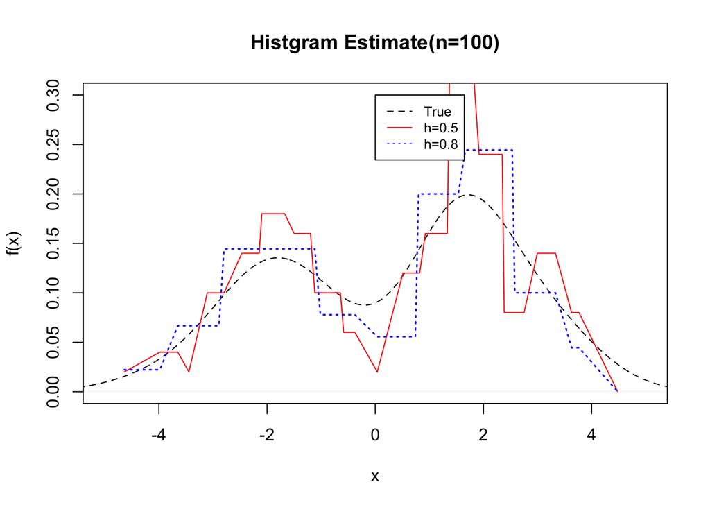

#### 比較三種方法 h=0.5 下的樣子

- 由圖可以看出 histogram 的估計方法震盪最大， naïve 則可看出資料的局部特性，而 normal kernel 的曲線最為平滑。

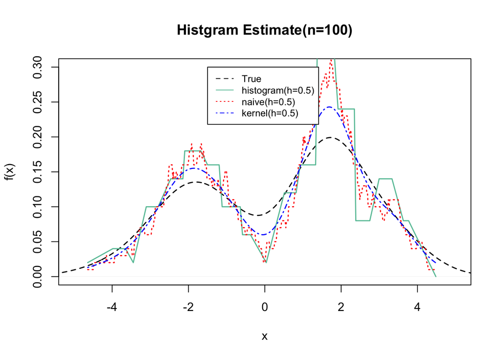

## 第六題

Visit the webpage of Department of Statistics, Ministry of Interior of the Taiwan Government (www.moi.gov.tw/stat) and download the age-specific death records of year 2015. Use the smoothing techniques introduced in class to revise the age-specific mortality rates and compare with the values from 2015 Taiwan abridged life table. You only need to consider the case of the male or female.

```r
data=read.csv("/Users/apple/nicole/R code/classR/hw5_death.csv", fileEncoding = "big5")
d=data$d[1:85]
e=data$e[1:85]
t=sqrt(0:84)
pois.fit=gssanova((d/e)~t,family="poisson",weights=e)
est1=predict(pois.fit,data.frame(t=t),se=TRUE)
poi.lowess=lowess(log(d/e),f=0.05)
```

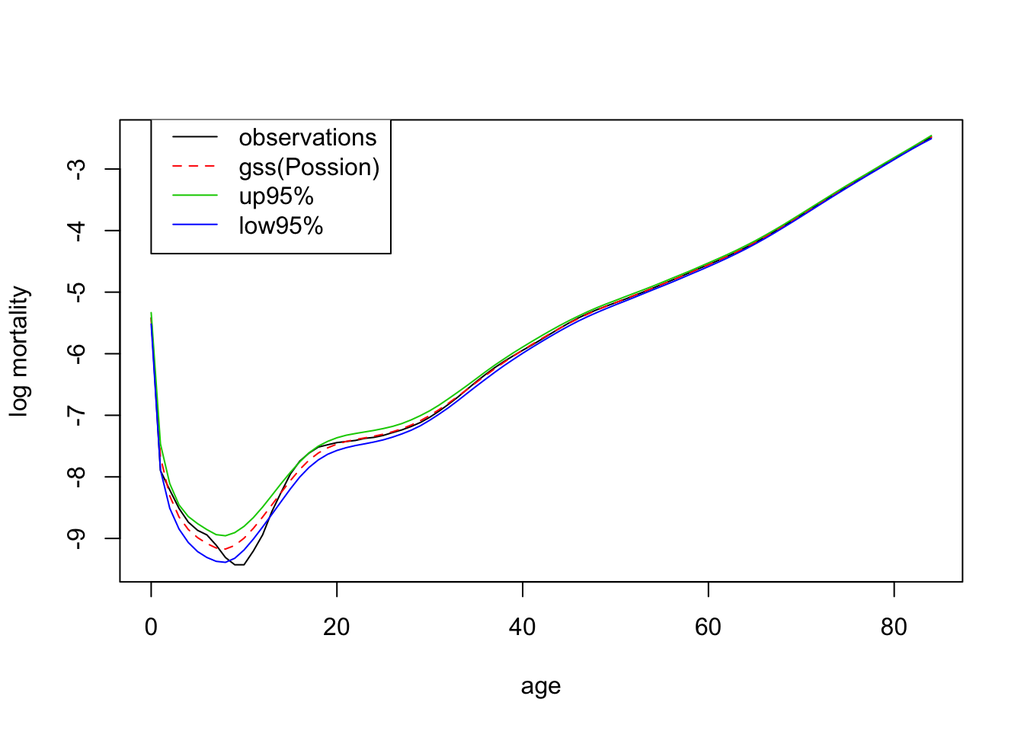

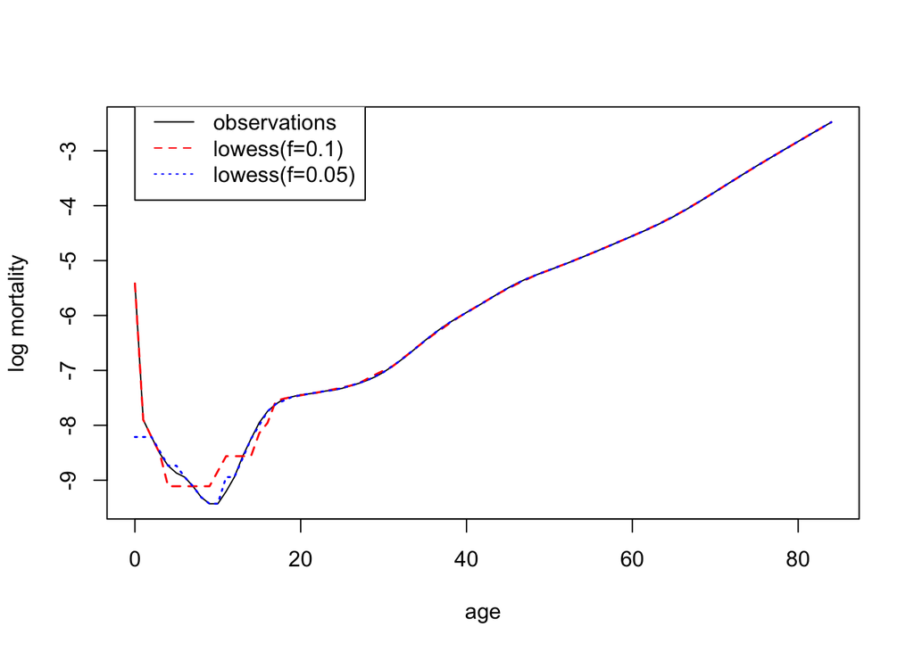

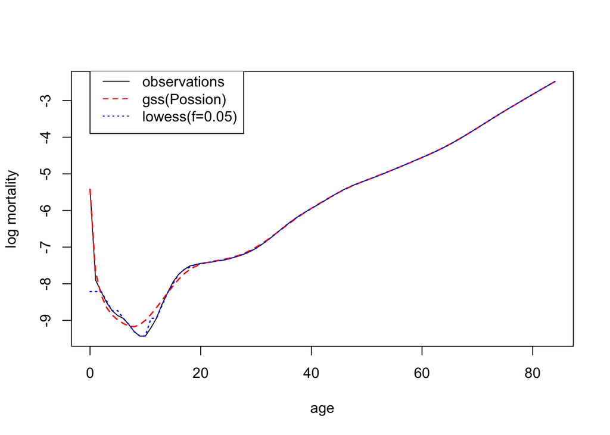